# Project: Identify Customer Segments

### Step 2.3: Interpret Principal Components

Now that we have our transformed principal components, it's a nice idea to check out the weight of each variable on the first few components to see if they can be interpreted in some fashion.

As a reminder, each principal component is a unit vector that points in the direction of highest variance (after accounting for the variance captured by earlier principal components). The further a weight is from zero, the more the principal component is in the direction of the corresponding feature. If two features have large weights of the same sign (both positive or both negative), then increases in one tend expect to be associated with increases in the other. To contrast, features with different signs can be expected to show a negative correlation: increases in one variable should result in a decrease in the other.

- To investigate the features, you should map each weight to their corresponding feature name, then sort the features according to weight. The most interesting features for each principal component, then, will be those at the beginning and end of the sorted list. Use the data dictionary document to help you understand these most prominent features, their relationships, and what a positive or negative value on the principal component might indicate.
- You should investigate and interpret feature associations from the first three principal components in this substep. To help facilitate this, you should write a function that you can call at any time to print the sorted list of feature weights, for the *i*-th principal component. This might come in handy in the next step of the project, when you interpret the tendencies of the discovered clusters.

```python
df = pd.DataFrame(pca_retain.components_, columns=azdias_clean.columns)
df.shape
```

```
(25, 81)
```

```python
df.head()
```

|  | ALTERSKATEGORIE_GROB | ANREDE_KZ | CJT_GESAMTTYP | FINANZ_MINIMALIST | FINANZ_SPARER | FINANZ_VORSORGER | FINANZ_ANLEGER | FINANZ_UNAUFFAELLIGER | FINANZ_HAUSBAUER | FINANZTYP | ... | PLZ8_BAUMAX | PLZ8_HHZ | PLZ8_GBZ | ARBEIT | ORTSGR_KLS9 | RELAT_AB | PRAEGENDE_JUGENDJAHRE_decade | PRAEGENDE_JUGENDJAHRE_movement | CAMEO_INTL_2015_wealth | CAMEO_INTL_2015_life_stage |
| --- | --- | --- | --- | --- | --- | --- | --- | --- | --- | --- | --- | --- | --- | --- | --- | --- | --- | --- | --- | --- | --- |
| 0 | -0.086560 | 0.007861 | 0.030048 | -0.187249 | 0.108744 | -0.083129 | 0.047967 | 0.048158 | 0.146707 | -0.045416 | ... | 0.179982 | 0.031738 | -0.143599 | 0.119945 | 0.158146 | 0.108850 | 0.071184 | -0.113409 | 0.189003 | -0.113666 |
| 1 | 0.264277 | 0.072681 | -0.124534 | 0.091507 | -0.242907 | 0.230802 | -0.205210 | -0.228293 | 0.088936 | 0.114128 | ... | 0.056701 | 0.006028 | -0.051287 | 0.048346 | 0.061085 | 0.044230 | -0.253303 | -0.006287 | 0.049044 | 0.009292 |
| 2 | 0.064813 | -0.362902 | -0.027925 | 0.153075 | -0.087267 | 0.082344 | -0.172674 | -0.083582 | -0.055659 | 0.110973 | ... | 0.048120 | 0.004878 | -0.038074 | 0.033938 | 0.047202 | 0.029760 | -0.092005 | 0.052075 | 0.025972 | -0.012595 |
| 3 | -0.004065 | 0.035574 | 0.068568 | 0.021985 | -0.003411 | -0.001553 | -0.053547 | 0.006250 | -0.032794 | 0.017452 | ... | 0.126931 | 0.027607 | -0.099284 | 0.101384 | 0.201022 | 0.108285 | 0.020110 | 0.175941 | 0.007947 | -0.007106 |
| 4 | 0.061700 | -0.029953 | -0.018537 | -0.015957 | -0.013804 | 0.031599 | 0.107220 | -0.108821 | 0.054099 | 0.064985 | ... | -0.017251 | -0.132435 | -0.075947 | -0.011972 | -0.184024 | -0.049403 | -0.031402 | -0.285354 | 0.163670 | -0.086719 |

5 rows × 81 columns

```python
# Map weights for the first principal component to corresponding feature names
# and then print the linked values, sorted by weight.
# HINT: Try defining a function here or in a new cell that you can reuse in the
# other cells.
def plotFeaWeight(componentNo, df):

    weights = df.iloc[componentNo, :]
    weights = weights.sort_values(ascending=False)

    plt.figure(figsize=(15,6))
    plt.xticks(np.arange(len(weights)), weights.index, rotation=90)
    plt.title('Feature Weights')
    plt.plot(np.arange(len(weights)), weights, '*g')

    for weight in weights.index:
        weights[weight] = df.iloc[componentNo, :][weight]

    return weights
```

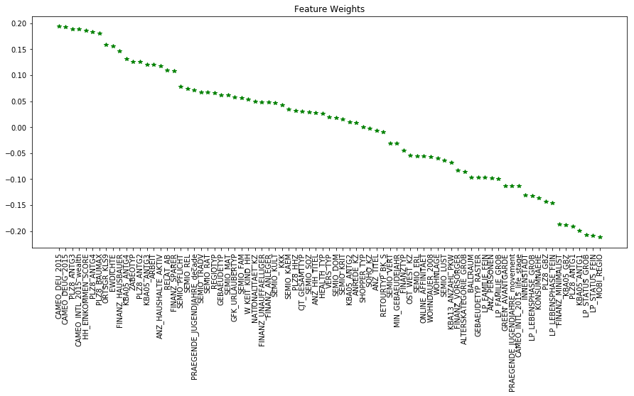

```python
weights_1 = plotFeaWeight(0, df)
```

```python
weights_1
```

```
CAMEO_DEU_2015                    0.193525
CAMEO_DEUG_2015                   0.192327
PLZ8_ANTG3                        0.189051
CAMEO_INTL_2015_wealth            0.189003
HH_EINKOMMEN_SCORE                0.185916
PLZ8_ANTG4                        0.183281
PLZ8_BAUMAX                       0.179982
ORTSGR_KLS9                       0.158146
EWDICHTE                          0.155362
FINANZ_HAUSBAUER                  0.146707
KBA05_ANTG4                       0.130994
ZABEOTYP                          0.126369
PLZ8_ANTG2                        0.125912
KBA05_ANTG3                       0.120407
ARBEIT                            0.119945
ANZ_HAUSHALTE_AKTIV               0.117934
RELAT_AB                          0.108850
FINANZ_SPARER                     0.108744
SEMIO_PFLICHT                     0.078495
SEMIO_REL                         0.073390
PRAEGENDE_JUGENDJAHRE_decade      0.071184
SEMIO_TRADV                       0.067615
SEMIO_RAT                         0.066541
REGIOTYP                          0.066057
GEBAEUDETYP                       0.062103
SEMIO_MAT                         0.061230
GFK_URLAUBERTYP                   0.057927
SEMIO_FAM                         0.055799
W_KEIT_KIND_HH                    0.053035
NATIONALITAET_KZ                  0.049723
                                    ...
FINANZTYP                        -0.045416
OST_WEST_KZ                      -0.054102
SEMIO_ERL                        -0.055196
ONLINE_AFFINITAET                -0.055896
WOHNDAUER_2008                   -0.056990
WOHNLAGE                         -0.059829
SEMIO_LUST                       -0.064657
KBA13_ANZAHL_PKW                 -0.068266
FINANZ_VORSORGER                 -0.083129
ALTERSKATEGORIE_GROB             -0.086560
BALLRAUM                         -0.096776
GEBAEUDETYP_RASTER               -0.097033
LP_FAMILIE_FEIN                  -0.097148
ANZ_PERSONEN                     -0.098397
LP_FAMILIE_GROB                  -0.098995
GREEN_AVANTGARDE                 -0.113409
PRAEGENDE_JUGENDJAHRE_movement   -0.113409
CAMEO_INTL_2015_life_stage       -0.113666
INNENSTADT                       -0.130614
LP_LEBENSPHASE_GROB              -0.132719
KONSUMNAEHE                      -0.137059
PLZ8_GBZ                         -0.143599
LP_LEBENSPHASE_FEIN              -0.146427
FINANZ_MINIMALIST                -0.187249
KBA05_GBZ                        -0.187932
PLZ8_ANTG1                       -0.191653
KBA05_ANTG1                      -0.199245
LP_STATUS_GROB                   -0.206912
LP_STATUS_FEIN                   -0.208276
MOBI_REGIO                       -0.211556
Name: 0, Length: 81, dtype: float64
```

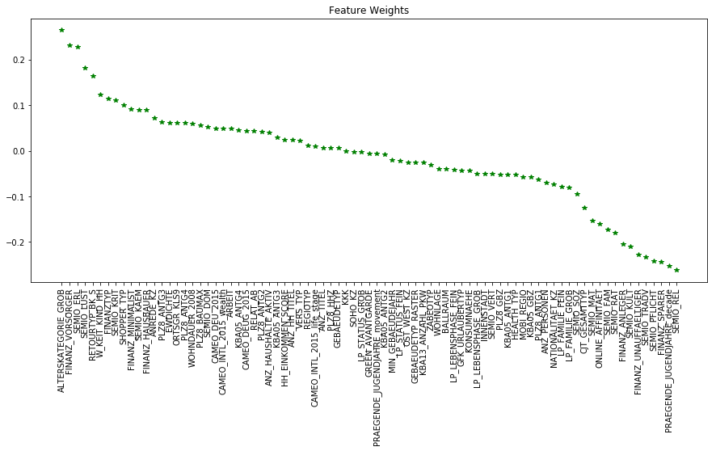

```python
# Map weights for the second principal component to corresponding feature names
# and then print the linked values, sorted by weight.
weights_2 = plotFeaWeight(1, df)
```

```python
weights_2
```

```
ALTERSKATEGORIE_GROB            0.264277
FINANZ_VORSORGER                0.230802
SEMIO_ERL                       0.227374
SEMIO_LUST                      0.182511
RETOURTYP_BK_S                  0.163989
W_KEIT_KIND_HH                  0.123191
FINANZTYP                       0.114128
SEMIO_KRIT                      0.110081
SHOPPER_TYP                     0.101119
FINANZ_MINIMALIST               0.091507
SEMIO_KAEM                      0.090055
FINANZ_HAUSBAUER                0.088936
ANREDE_KZ                       0.072681
PLZ8_ANTG3                      0.063682
EWDICHTE                        0.061378
ORTSGR_KLS9                     0.061085
PLZ8_ANTG4                      0.060563
WOHNDAUER_2008                  0.060365
PLZ8_BAUMAX                     0.056701
SEMIO_DOM                       0.053250
CAMEO_DEU_2015                  0.049447
CAMEO_INTL_2015_wealth          0.049044
ARBEIT                          0.048346
KBA05_ANTG4                     0.045306
CAMEO_DEUG_2015                 0.044346
RELAT_AB                        0.044230
PLZ8_ANTG2                      0.041696
ANZ_HAUSHALTE_AKTIV             0.040572
KBA05_ANTG3                     0.029355
HH_EINKOMMEN_SCORE              0.024747
                                  ...
LP_LEBENSPHASE_FEIN            -0.041597
GFK_URLAUBERTYP                -0.043011
KONSUMNAEHE                    -0.043498
LP_LEBENSPHASE_GROB            -0.049924
INNENSTADT                     -0.049998
SEMIO_VERT                     -0.050551
PLZ8_GBZ                       -0.051287
KBA05_ANTG1                    -0.052169
HEALTH_TYP                     -0.052894
MOBI_REGIO                     -0.057357
KBA05_GBZ                      -0.058008
PLZ8_ANTG1                     -0.063056
ANZ_PERSONEN                   -0.069215
NATIONALITAET_KZ               -0.073493
LP_FAMILIE_FEIN                -0.079217
LP_FAMILIE_GROB                -0.079921
SEMIO_SOZ                      -0.095548
CJT_GESAMTTYP                  -0.124534
SEMIO_MAT                      -0.153684
ONLINE_AFFINITAET              -0.160339
SEMIO_FAM                      -0.172548
SEMIO_RAT                      -0.180543
FINANZ_ANLEGER                 -0.205210
SEMIO_KULT                     -0.210274
FINANZ_UNAUFFAELLIGER          -0.228293
SEMIO_TRADV                    -0.232454
SEMIO_PFLICHT                  -0.241760
FINANZ_SPARER                  -0.242907
PRAEGENDE_JUGENDJAHRE_decade   -0.253303
SEMIO_REL                      -0.261272
Name: 1, Length: 81, dtype: float64
```

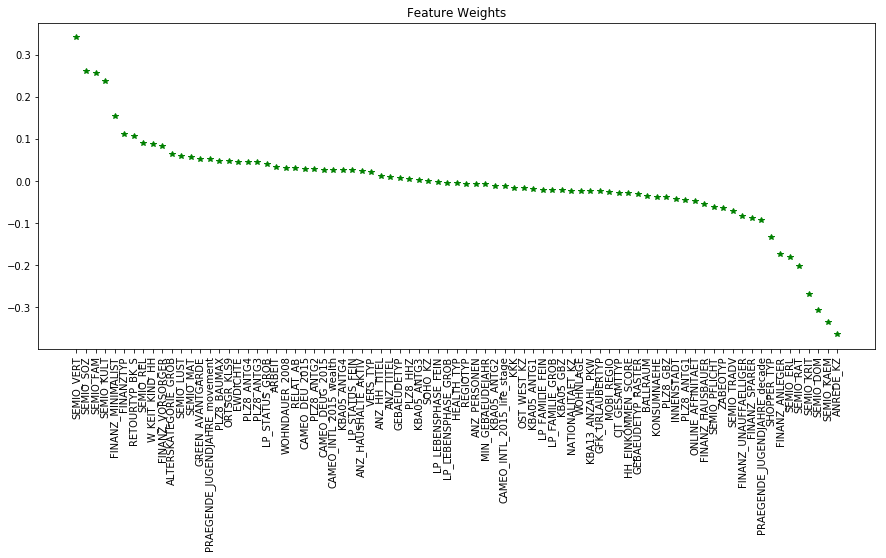

```python
# Map weights for the third principal component to corresponding feature names
# and then print the linked values, sorted by weight.
weights_3 = plotFeaWeight(2, df)
```

```python
weights_3
```

```
SEMIO_VERT                        0.340589
SEMIO_SOZ                         0.260513
SEMIO_FAM                         0.255211
SEMIO_KULT                        0.237997
FINANZ_MINIMALIST                 0.153075
FINANZTYP                         0.110973
RETOURTYP_BK_S                    0.105664
SEMIO_REL                         0.090588
W_KEIT_KIND_HH                    0.088904
FINANZ_VORSORGER                  0.082344
ALTERSKATEGORIE_GROB              0.064813
SEMIO_LUST                        0.058825
SEMIO_MAT                         0.057194
GREEN_AVANTGARDE                  0.052075
PRAEGENDE_JUGENDJAHRE_movement    0.052075
PLZ8_BAUMAX                       0.048120
ORTSGR_KLS9                       0.047202
EWDICHTE                          0.046106
PLZ8_ANTG4                        0.045466
PLZ8_ANTG3                        0.044091
LP_STATUS_GROB                    0.040360
ARBEIT                            0.033938
WOHNDAUER_2008                    0.030067
RELAT_AB                          0.029760
CAMEO_DEU_2015                    0.028693
PLZ8_ANTG2                        0.028028
CAMEO_DEUG_2015                   0.026416
CAMEO_INTL_2015_wealth            0.025972
KBA05_ANTG4                       0.025738
LP_STATUS_FEIN                    0.025715
                                    ...
KBA05_GBZ                        -0.021833
NATIONALITAET_KZ                 -0.022499
WOHNLAGE                         -0.022819
KBA13_ANZAHL_PKW                 -0.023392
GFK_URLAUBERTYP                  -0.024094
MOBI_REGIO                       -0.025723
CJT_GESAMTTYP                    -0.027925
HH_EINKOMMEN_SCORE               -0.028798
GEBAEUDETYP_RASTER               -0.030742
BALLRAUM                         -0.034426
KONSUMNAEHE                      -0.037595
PLZ8_GBZ                         -0.038074
INNENSTADT                       -0.043002
PLZ8_ANTG1                       -0.045445
ONLINE_AFFINITAET                -0.048027
FINANZ_HAUSBAUER                 -0.055659
SEMIO_PFLICHT                    -0.060955
ZABEOTYP                         -0.064958
SEMIO_TRADV                      -0.070477
FINANZ_UNAUFFAELLIGER            -0.083582
FINANZ_SPARER                    -0.087267
PRAEGENDE_JUGENDJAHRE_decade     -0.092005
SHOPPER_TYP                      -0.133656
FINANZ_ANLEGER                   -0.172674
SEMIO_ERL                        -0.180119
SEMIO_RAT                        -0.202524
SEMIO_KRIT                       -0.267238
SEMIO_DOM                        -0.306670
SEMIO_KAEM                       -0.333835
ANREDE_KZ                        -0.362902
Name: 2, Length: 81, dtype: float64
```

### Discussion 2.3: Interpret Principal Components

(Double-click this cell and replace this text with your own text, reporting your observations from detailed investigation of the first few principal components generated. Can we interpret positive and negative values from them in a meaningful way?)

A: For the first latent feature feature 'CAMEO_DEU_2015' and 'MOBI_REGIO' are the beginning and the end of the list. and the two features have almost the same weights and opposite signs. This means they influence the first component in the opposite way. The reason is perhaps the most wealthy people have more stable life so they don't need to move around.

For the second latent feature 'ALTERSKATEGORIE_GROB' is at the beginning while 'SEMIO_REL' at the end. They also have almost the same weight and the opposite signs. I don't quite know the meaning of 'SEMIO_REL', but I can explain association between feature 'ALTERSKATEGORIE_GROB' and the second end feature 'PRAEGENDE_JUGENDJAHRE_decade'. The younger people in 'ALTERSKATEGORIE_GROB' group, the later in feature 'PRAEGENDE_JUGENDJAHRE_decade' group.

For the third latent feature 'SEMIO_VERT' is at the beginning while 'ANREDE_KZ' at the end. almost the same weight and the opposite directions.

## Step 3: Clustering

### Step 3.1: Apply Clustering to General Population

You've assessed and cleaned the demographics data, then scaled and transformed them. Now, it's time to see how the data clusters in the principal components space. In this substep, you will apply k-means clustering to the dataset and use the average within-cluster distances from each point to their assigned cluster's centroid to decide on a number of clusters to keep.

- Use sklearn's KMeans class to perform k-means clustering on the PCA-transformed data.
- Then, compute the average difference from each point to its assigned cluster's center. **Hint**: The KMeans object's `.score()` method might be useful here, but note that in sklearn, scores tend to be defined so that larger is better. Try applying it to a small, toy dataset, or use an internet search to help your understanding.
- Perform the above two steps for a number of different cluster counts. You can then see how the average distance decreases with an increasing number of clusters. However, each additional cluster provides a smaller net benefit. Use this fact to select a final number of clusters in which to group the data. **Warning**: because of the large size of the dataset, it can take a long time for the algorithm to resolve. The more clusters to fit, the longer the algorithm will take. You should test for cluster counts through at least 10 clusters to get the full picture, but you shouldn't need to test for a number of clusters above about 30.
- Once you've selected a final number of clusters to use, re-fit a KMeans instance to perform the clustering operation. Make sure that you also obtain the cluster assignments for the general demographics data, since you'll be using them in the final Step 3.3.

```python
scores = []

# Over a number of different cluster counts...
for n in range(3, 30, 3):
    # run k-means clustering on the data and...
    kmeans = KMeans(n_clusters=n)
    model = kmeans.fit(azdias_pca_retain)

    # compute the average within-cluster distances.
    score = np.abs(model.score(azdias_pca_retain))

    scores.append(score)
    print('%2d centroid, score: %.3f' % (n, score))
```

```
 3 centroid, score: 30219145.743
 6 centroid, score: 26209173.836
 9 centroid, score: 23844581.606
12 centroid, score: 22636879.151
15 centroid, score: 21444088.241
18 centroid, score: 20487589.755
21 centroid, score: 19812135.400
24 centroid, score: 19225690.097
27 centroid, score: 18776528.069
```

```
Text(0.5,1,'Scree Plot')
```

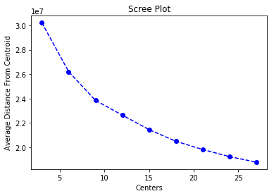

```python
# Investigate the change in within-cluster distance across number of clusters.
# HINT: Use matplotlib's plot function to visualize this relationship.
centers = list(range(3, 30, 3))

plt.plot(centers, scores, linestyle='--', marker='o', color='b')
plt.xlabel('Centers')
plt.ylabel('Average Distance From Centroid')
plt.title('Scree Plot')
```

```python
# Re-fit the k-means model with the selected number of clusters and obtain
# cluster predictions for the general population demographics data.
kmean = KMeans(n_clusters=9).fit(azdias_pca_retain)
azdias_preds = kmean.predict(azdias_pca_retain)
```

### Discussion 3.1: Apply Clustering to General Population

(Double-click this cell and replace this text with your own text, reporting your findings and decisions regarding clustering. Into how many clusters have you decided to segment the population?)

A: from 9 the distance begin to decrease slowly, so I will seprate the points into 9 clusters.

### Step 3.2: Apply All Steps to the Customer Data

Now that you have clusters and cluster centers for the general population, it's time to see how the customer data maps on to those clusters. Take care to not confuse this for re-fitting all of the models to the customer data. Instead, you're going to use the fits from the general population to clean, transform, and cluster the customer data. In the last step of the project, you will interpret how the general population fits apply to the customer data.

- Don't forget when loading in the customers data, that it is semicolon (`;`) delimited.
- Apply the same feature wrangling, selection, and engineering steps to the customer demographics using the `clean_data()` function you created earlier. (You can assume that the customer demographics data has similar meaning behind missing data patterns as the general demographics data.)
- Use the sklearn objects from the general demographics data, and apply their transformations to the customers data. That is, you should not be using a `.fit()` or `.fit_transform()` method to re-fit the old objects, nor should you be creating new sklearn objects! Carry the data through the feature scaling, PCA, and clustering steps, obtaining cluster assignments for all of the data in the customer demographics data.

```python
# Load in the customer demographics data.
customers = pd.read_csv('./Udacity_CUSTOMERS_Subset.csv', sep=';')
```

```python
customers.head()
```

|  | AGER_TYP | ALTERSKATEGORIE_GROB | ANREDE_KZ | CJT_GESAMTTYP | FINANZ_MINIMALIST | FINANZ_SPARER | FINANZ_VORSORGER | FINANZ_ANLEGER | FINANZ_UNAUFFAELLIGER | FINANZ_HAUSBAUER | ... | PLZ8_ANTG1 | PLZ8_ANTG2 | PLZ8_ANTG3 | PLZ8_ANTG4 | PLZ8_BAUMAX | PLZ8_HHZ | PLZ8_GBZ | ARBEIT | ORTSGR_KLS9 | RELAT_AB |
| --- | --- | --- | --- | --- | --- | --- | --- | --- | --- | --- | --- | --- | --- | --- | --- | --- | --- | --- | --- | --- | --- |
| 0 | 2 | 4 | 1 | 5.0 | 5 | 1 | 5 | 1 | 2 | 2 | ... | 3.0 | 3.0 | 1.0 | 0.0 | 1.0 | 5.0 | 5.0 | 1.0 | 2.0 | 1.0 |
| 1 | -1 | 4 | 1 | NaN | 5 | 1 | 5 | 1 | 3 | 2 | ... | NaN | NaN | NaN | NaN | NaN | NaN | NaN | NaN | NaN | NaN |
| 2 | -1 | 4 | 2 | 2.0 | 5 | 1 | 5 | 1 | 4 | 4 | ... | 2.0 | 3.0 | 3.0 | 1.0 | 3.0 | 3.0 | 2.0 | 3.0 | 5.0 | 3.0 |
| 3 | 1 | 4 | 1 | 2.0 | 5 | 1 | 5 | 2 | 1 | 2 | ... | 3.0 | 2.0 | 1.0 | 0.0 | 1.0 | 3.0 | 4.0 | 1.0 | 3.0 | 1.0 |
| 4 | -1 | 3 | 1 | 6.0 | 3 | 1 | 4 | 4 | 5 | 2 | ... | 2.0 | 4.0 | 2.0 | 1.0 | 2.0 | 3.0 | 3.0 | 3.0 | 5.0 | 1.0 |

5 rows × 85 columns

```python
# Apply preprocessing, feature transformation, and clustering from the general
# demographics onto the customer data, obtaining cluster predictions for the
# customer demographics data.
customers_clean = clean_data(customers)
```

```python
customers_clean.head()
```

|  | ALTERSKATEGORIE_GROB | ANREDE_KZ | CJT_GESAMTTYP | FINANZ_MINIMALIST | FINANZ_SPARER | FINANZ_VORSORGER | FINANZ_ANLEGER | FINANZ_UNAUFFAELLIGER | FINANZ_HAUSBAUER | FINANZTYP | ... | PLZ8_BAUMAX | PLZ8_HHZ | PLZ8_GBZ | ARBEIT | ORTSGR_KLS9 | RELAT_AB | PRAEGENDE_JUGENDJAHRE_decade | PRAEGENDE_JUGENDJAHRE_movement | CAMEO_INTL_2015_wealth | CAMEO_INTL_2015_life_stage |
| --- | --- | --- | --- | --- | --- | --- | --- | --- | --- | --- | --- | --- | --- | --- | --- | --- | --- | --- | --- | --- | --- |
| 0 | 4.0 | 1 | 5.0 | 5 | 1 | 5 | 1 | 2 | 2 | 2 | ... | 1.0 | 5.0 | 5.0 | 1.0 | 2.0 | 1.0 | 2.0 | 1.0 | 1.0 | 3.0 |
| 2 | 4.0 | 2 | 2.0 | 5 | 1 | 5 | 1 | 4 | 4 | 2 | ... | 3.0 | 3.0 | 2.0 | 3.0 | 5.0 | 3.0 | 2.0 | 1.0 | 3.0 | 4.0 |
| 4 | 3.0 | 1 | 6.0 | 3 | 1 | 4 | 4 | 5 | 2 | 2 | ... | 2.0 | 3.0 | 3.0 | 3.0 | 5.0 | 1.0 | 4.0 | 0.0 | 4.0 | 1.0 |
| 5 | 3.0 | 1 | 4.0 | 5 | 1 | 5 | 1 | 2 | 3 | 5 | ... | 1.0 | 5.0 | 5.0 | 3.0 | 7.0 | 5.0 | 2.0 | 1.0 | 3.0 | 4.0 |
| 6 | 4.0 | 1 | 2.0 | 5 | 1 | 5 | 1 | 1 | 2 | 2 | ... | 1.0 | 5.0 | 5.0 | 2.0 | 3.0 | 2.0 | 2.0 | 1.0 | 2.0 | 3.0 |

5 rows × 79 columns

```python
std = p.StandardScaler()
customers_ss = std.fit_transform(customers_clean)
customers_pca_retain  = pca_retain.fit_transform(customers_ss)
```

```python
customers_preds = kmean.predict(customers_pca_retain)
```

```python
customers_preds.shape
```

```
(121111,)
```

### Step 3.3: Compare Customer Data to Demographics Data

At this point, you have clustered data based on demographics of the general population of Germany, and seen how the customer data for a mail-order sales company maps onto those demographic clusters. In this final substep, you will compare the two cluster distributions to see where the strongest customer base for the company is.

Consider the proportion of persons in each cluster for the general population, and the proportions for the customers. If we think the company's customer base to be universal, then the cluster assignment proportions should be fairly similar between the two. If there are only particular segments of the population that are interested in the company's products, then we should see a mismatch from one to the other. If there is a higher proportion of persons in a cluster for the customer data compared to the general population (e.g. 5% of persons are assigned to a cluster for the general population, but 15% of the customer data is closest to that cluster's centroid) then that suggests the people in that cluster to be a target audience for the company. On the other hand, the proportion of the data in a cluster being larger in the general population than the customer data (e.g. only 2% of customers closest to a population centroid that captures 6% of the data) suggests that group of persons to be outside of the target demographics.

Take a look at the following points in this step:

- Compute the proportion of data points in each cluster for the general population and the customer data. Visualizations will be useful here: both for the individual dataset proportions, but also to visualize the ratios in cluster representation between groups. Seaborn's [`countplot()`](https://seaborn.pydata.org/generated/seaborn.countplot.html) or [`barplot()`](https://seaborn.pydata.org/generated/seaborn.barplot.html) function could be handy.
  - Recall the analysis you performed in step 1.1.3 of the project, where you separated out certain data points from the dataset if they had more than a specified threshold of missing values. If you found that this group was qualitatively different from the main bulk of the data, you should treat this as an additional data cluster in this analysis. Make sure that you account for the number of data points in this subset, for both the general population and customer datasets, when making your computations!
- Which cluster or clusters are overrepresented in the customer dataset compared to the general population? Select at least one such cluster and infer what kind of people might be represented by that cluster. Use the principal component interpretations from step 2.3 or look at additional components to help you make this inference. Alternatively, you can use the `.inverse_transform()` method of the PCA and StandardScaler objects to transform centroids back to the original data space and interpret the retrieved values directly.
- Perform a similar investigation for the underrepresented clusters. Which cluster or clusters are underrepresented in the customer dataset compared to the general population, and what kinds of people are typified by these clusters?

```
Text(0.5,1,'Clustering Customers')
```

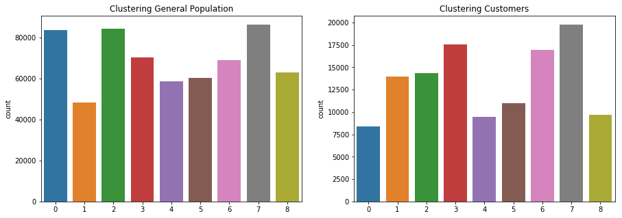

```python
# Compare the proportion of data in each cluster for the customer data to the
# proportion of data in each cluster for the general population.
plt.figure(figsize=(15,5))
plt.subplot(1, 2, 1)
countplot(azdias_preds)
plt.title('Clustering General Population')

plt.subplot(1, 2, 2)
countplot(customers_preds)
plt.title('Clustering Customers')
```

```python
# What kinds of people are part of a cluster that is overrepresented in the
# customer data compared to the general population?

# Cluster 1 is overrepresented, thus this cluster is the target audience
df_pca_retain_var = pd.DataFrame(pca_retain.components_, columns=customers_clean.columns)
df_customers_pca_retain = pd.DataFrame(customers_pca_retain, index=customers_clean.index)
df_customers_pca_retain['preds'] = customers_preds

cluster_1 = df_customers_pca_retain.loc[df_customers_pca_retain['preds']==1, :].iloc[:, :-1]
cluster_1_ss = pca_retain.inverse_transform(cluster_1)
cluster_1_origin = std.inverse_transform(cluster_1_ss)
df_cluster_1_origin = pd.DataFrame(cluster_1_origin, columns=customers_clean.columns)
```

```python
df_cluster_1_origin
```

[output not shown]

13972 rows × 79 columns

```python
# From the feature above we could infer that people above 46 years old, female who have financial capital...
# are likely to be the audience
```

```python
# What kinds of people are part of a cluster that is underrepresented in the
# customer data compared to the general population?

# Cluster 0 is underrepresented, thus this cluster should be outside of the target.
df_pca_retain_var = pd.DataFrame(pca_retain.components_, columns=customers_clean.columns)
df_customers_pca_retain = pd.DataFrame(customers_pca_retain, index=customers_clean.index)
df_customers_pca_retain['preds'] = customers_preds

cluster_0 = df_customers_pca_retain.loc[df_customers_pca_retain['preds']==0, :].iloc[:, :-1]
cluster_0_ss = pca_retain.inverse_transform(cluster_0)
cluster_0_origin = std.inverse_transform(cluster_0_ss)
df_cluster_0_origin = pd.DataFrame(cluster_0_origin, columns=customers_clean.columns)
```

```python
df_cluster_0_origin
```

[output not shown]

8405 rows × 79 columns

```python
# Younger people under age 40, male, unemployed in a big community are outside of our target.
```

### Discussion 3.3: Compare Customer Data to Demographics Data

(Double-click this cell and replace this text with your own text, reporting findings and conclusions from the clustering analysis. Can we describe segments of the population that are relatively popular with the mail-order company, or relatively unpopular with the company?)

A: Yes, from the overrepresenting and the underrepresenting of the general population we could infer if a certain segment is relatively popular or unpopular with the mail-oder company.

> Congratulations on making it this far in the project! Before you finish, make sure to check through the entire notebook from top to bottom to make sure that your analysis follows a logical flow and all of your findings are documented in **Discussion** cells. Once you've checked over all of your work, you should export the notebook as an HTML document to submit for evaluation. You can do this from the menu, navigating to **File -> Download as -> HTML (.html)**. You will submit both that document and this notebook for your project submission.